# FinalProject2820L

Daniel Zhang

5/1/2022

Daniel Zhang MATH 2820L Final Project

### Introduction

In this project, we want to explore a Unicorn company’s dataset available at link: https://www.kaggle.com/datasets/deepcontractor/unicorn-companies-dataset. This dataset contains 1037 companies and 13 columns to categorize them, such as Valuation, Date Joined, Country, City, Industry, Total Raised, etc. A unicorn company refers to a privately held startup company that has a valuation exceeding $1 billion. Some of the most well-known unicorns include Robinhood, Airbnb, etc. In this project, we are interested in the trends of the Unicorn companies and possible relationships between the aforementioned categories. For instance, we are curious about whether the amount of money raised would have an impact on the market evaluation of the company. Or if a specific U.S. city produces more Unicorn companies than others.

### Data cleaning

Before we went into the analysis process, we noticed several problems within the dataset. For instance, the data entries in the Valuation column are all characters instead of numbers. Thus we converted all entries into numericals. Similarly, we replaced all the ‘M’ and ‘B’ letters in Total Raised with corresponding monetary values and converted the entries into numerics. In addition, we converted the characters into calendar dates for the Date Joined column. And we noticed Fintech was spelled differently occasionally, so we converted all instances of the alternative spelling to Fintech. Finally, we took the log of all economic data since it’s standard to do so.

```r
library(tidyverse)
```

```r
library(stringr)
library(ggplot2)
library(doBy)
uni_company <-read.csv("Unicorn_Companies.csv")



uni_company = uni_company %>%
  mutate(Valuation...B. = gsub('[$]', '', Valuation...B.)) %>%
  mutate(Valuation...B. = as.numeric(Valuation...B.)) %>%
  mutate(Valuation...B. = Valuation...B. * 1000000000) %>%
  mutate(Total.Raised = gsub('[$]', '', Total.Raised)) %>%
  mutate(Total.Raised = as.numeric(str_replace_all(Total.Raised, setNames(c("e6", "e9"), c("M", "B"))))) %>%
  #filter(Country == "United States") %>%
  mutate(Total.Raised = log(Total.Raised)) %>%
  mutate(Valuation...B. = log(Valuation...B.)) %>%
  mutate(Date.Joined = as.Date(Date.Joined, "%m/%d/%Y"))
uni_company$Industry[uni_company$Industry == "Finttech"] <- "Fintech"
```

### Data Exploration

With a little bit of prior knowledge and some light exploration, we realized Country would have have some hard to predict effects on our data and introduce extra noise. Here’s a graph of mean log valuation by Country.

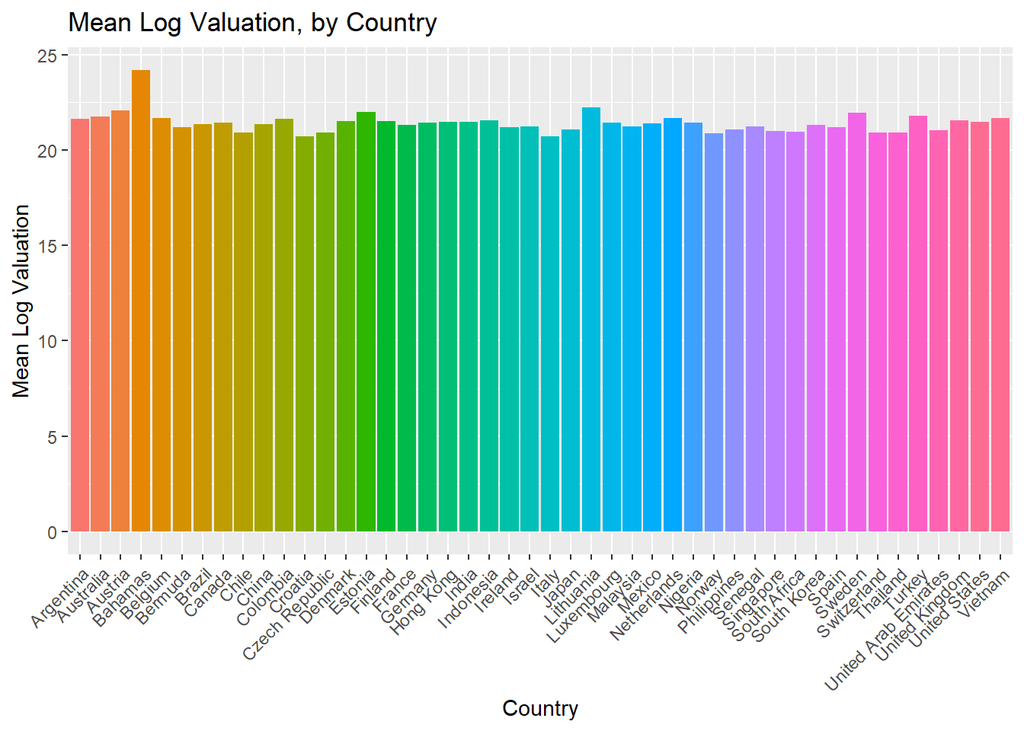

```r
uni_company$Country = factor(uni_company$Country)
ind_means <- summaryBy(Valuation...B.  ~ Country, data=uni_company , FUN=c(mean), na.rm=TRUE)
ggplot(ind_means, aes(x=Country, y=Valuation...B..mean, fill=Country)) +
   geom_bar(stat = "identity") +
   guides(fill = FALSE) +
  xlab("Country") + ylab("Mean Log Valuation") +
  theme(axis.text.x = element_text(angle = 45, hjust = 1))  +
  ggtitle("Mean Log Valuation, by Country")
```

First order of business was filtering out non-US entries. US Companies comprise the majority of our dataset anyways, and we intended to focus on the US originally. Companies outside of the US have different financial regulations and other conditions, which all affect valuation and would make it a little harder for us to analyze/interpret the data.

We continue with the rest of our data exploration. We wanted to investigate how different variables were related to Valuation. This dataset was about large venture-capital funded enterpreneur-ed companies, so we wanted to investigate how they reached their valuations. Here are some visualizations of some categorical/numerical variables against Valuation.

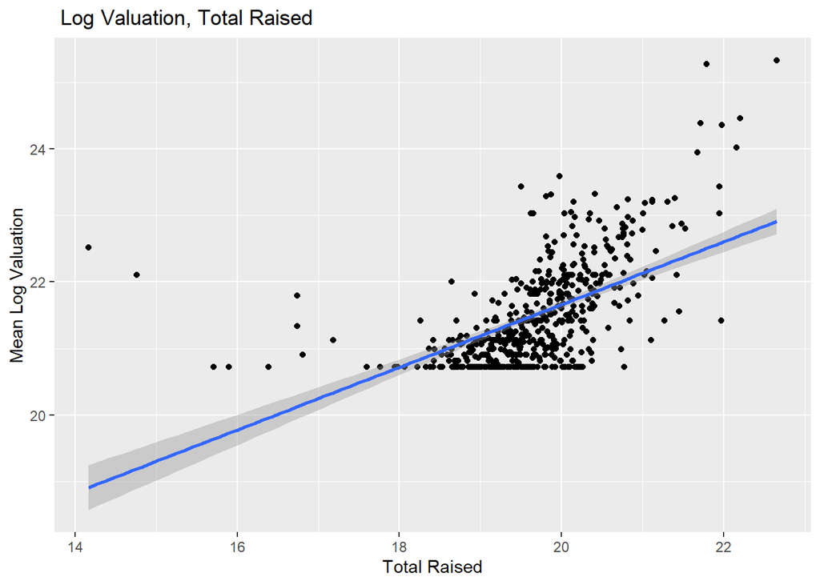

```r
uni_company = uni_company %>%
  filter(Country == "United States")

ggplot(uni_company, aes(x = Total.Raised, y = Valuation...B.)) +
    geom_point() +
    geom_smooth(method="lm") +
  xlab("Total Raised") + ylab("Mean Log Valuation") +
  ggtitle(" Log Valuation, Total Raised")
```

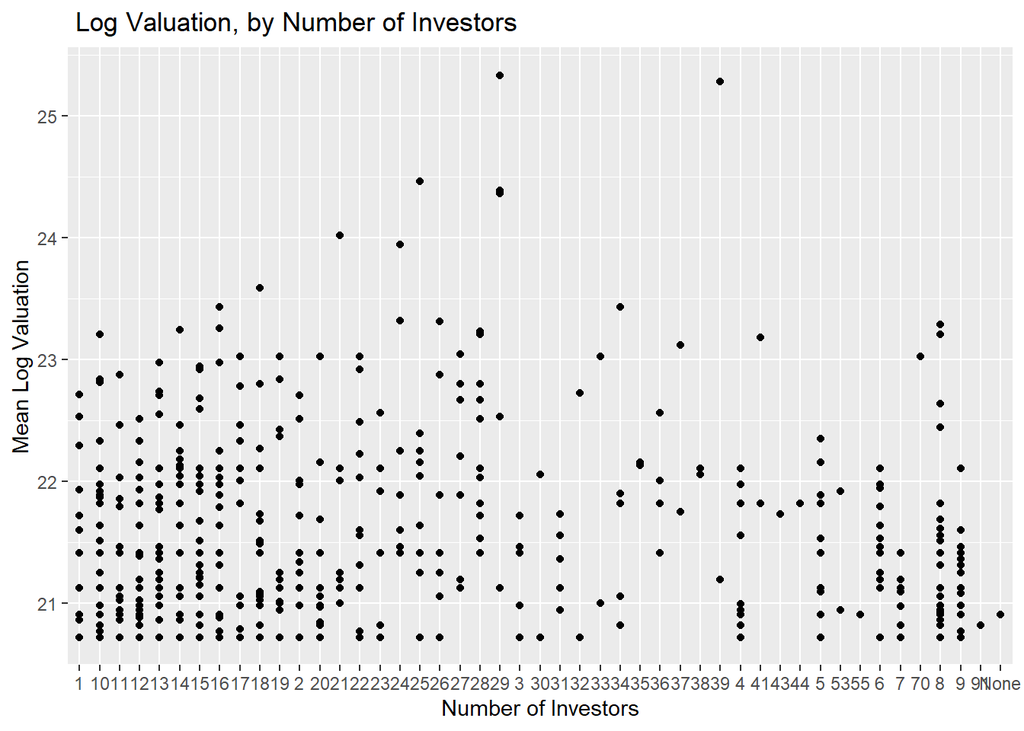

```r
ggplot(uni_company, aes(x = Investors.Count, y = Valuation...B.)) +
    geom_point() +
    geom_smooth(method="lm") +
  xlab("Number of Investors") + ylab("Mean Log Valuation") +
  ggtitle(" Log Valuation, by Number of Investors")
```

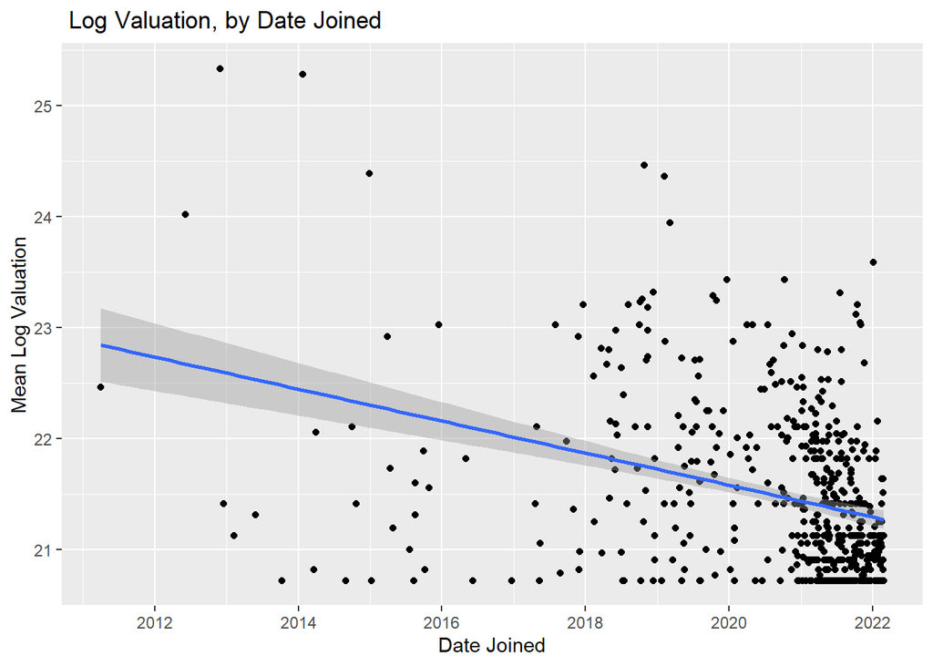

```r
ggplot(uni_company, aes(x = Date.Joined, y = Valuation...B.)) +
    geom_point() +
    geom_smooth(method="lm")+
  xlab("Date Joined") + ylab("Mean Log Valuation") +
  ggtitle(" Log Valuation, by Date Joined")
```

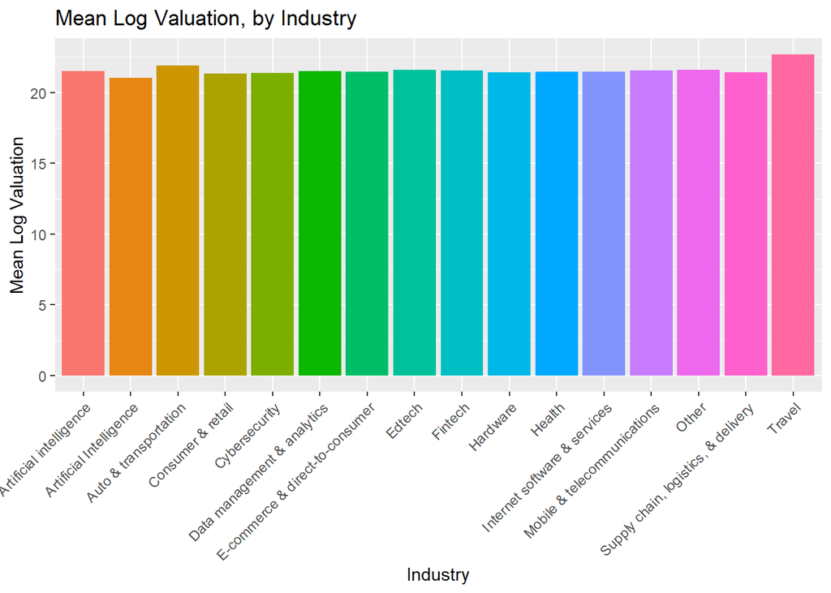

```r
uni_company$Industry = factor(uni_company$Industry)
ind_means <- summaryBy(Valuation...B.  ~ Industry, data=uni_company , FUN=c(mean), na.rm=TRUE)
ggplot(ind_means, aes(x=Industry, y=Valuation...B..mean, fill=Industry)) +
   geom_bar(stat = "identity") +
   guides(fill = FALSE) +
  xlab("Industry") + ylab("Mean Log Valuation") +
  theme(axis.text.x = element_text(angle = 45, hjust = 1))  +
  ggtitle("Mean Log Valuation, by Industry")
```

```r
IndustryLm = lm(Valuation...B. ~ Industry, uni_company)
summary(IndustryLm)
```

```
##
## Call:
## lm(formula = Valuation...B. ~ Industry, data = uni_company)
##
## Residuals:
##     Min      1Q  Median      3Q     Max
## -0.9937 -0.6156 -0.1885  0.4337  3.7484
##
## Coefficients:
##                                              Estimate Std. Error t value
## (Intercept)                                 21.507460   0.124040 173.391
## IndustryArtificial Intelligence             -0.478764   0.469608  -1.019
## IndustryAuto & transportation                0.391808   0.469608   0.834
## IndustryConsumer & retail                   -0.173816   0.267085  -0.651
## IndustryCybersecurity                       -0.145194   0.177712  -0.817
## IndustryData management & analytics          0.005154   0.187720   0.027
## IndustryE-commerce & direct-to-consumer     -0.016679   0.189474  -0.088
## IndustryEdtech                               0.094090   0.321411   0.293
## IndustryFintech                              0.029439   0.145024   0.203
## IndustryHardware                            -0.068714   0.277362  -0.248
## IndustryHealth                              -0.041339   0.166417  -0.248
## IndustryInternet software & services        -0.017810   0.140320  -0.127
## IndustryMobile & telecommunications          0.031443   0.258210   0.122
## IndustryOther                                0.075527   0.193302   0.391
## IndustrySupply chain, logistics, & delivery -0.078037   0.214843  -0.363
## IndustryTravel                               1.196807   0.794243   1.507
##                                             Pr(>|t|)
## (Intercept)                                   <2e-16 ***
## IndustryArtificial Intelligence                0.308
## IndustryAuto & transportation                  0.404
## IndustryConsumer & retail                      0.515
## IndustryCybersecurity                          0.414
## IndustryData management & analytics            0.978
## IndustryE-commerce & direct-to-consumer        0.930
## IndustryEdtech                                 0.770
## IndustryFintech                                0.839
## IndustryHardware                               0.804
## IndustryHealth                                 0.804
## IndustryInternet software & services           0.899
## IndustryMobile & telecommunications            0.903
## IndustryOther                                  0.696
## IndustrySupply chain, logistics, & delivery    0.717
## IndustryTravel                                 0.132
## ---
## Signif. codes:  0 '***' 0.001 '**' 0.01 '*' 0.05 '.' 0.1 ' ' 1
##
## Residual standard error: 0.7845 on 520 degrees of freedom
## Multiple R-squared:  0.01311,    Adjusted R-squared:  -0.01536
## F-statistic: 0.4604 on 15 and 520 DF,  p-value: 0.9591
```

```r
summary(IndustryLm)$r.squared
```

```
## [1] 0.01310776
```

```r
uni_company$City = factor(uni_company$City)

city_means <- summaryBy(Valuation...B.  ~ City, data=uni_company , FUN=c(mean), na.rm=TRUE)

print("Here are all the cities in the US and their mean valuations")
```

```
## [1] "Here are all the cities in the US and their mean valuations"
```

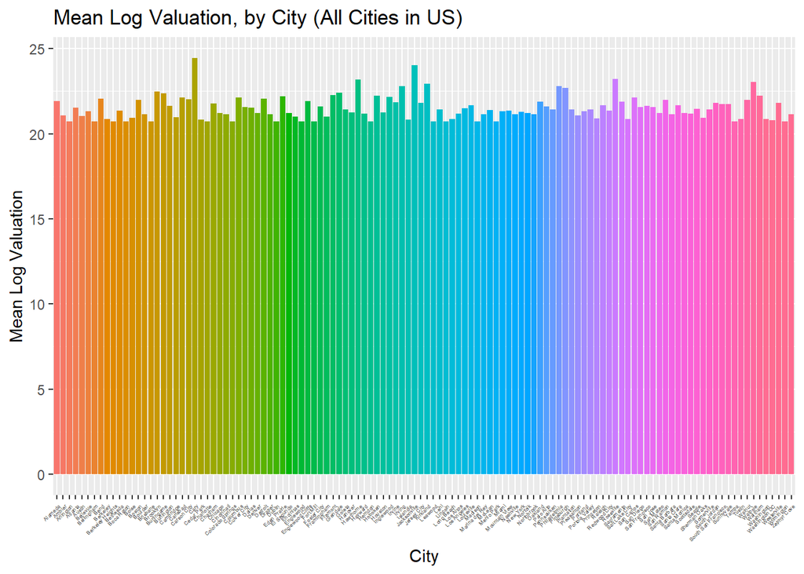

```r
ggplot(data=city_means, aes(x=City, y=Valuation...B..mean, fill=City)) +
   geom_bar(stat = "identity") +
   guides(fill = FALSE) +
  theme(axis.text.x = element_text(angle = 45, hjust = 1, size = 3.5))  +
  xlab("City") + ylab("Mean Log Valuation") +
  ggtitle("Mean Log Valuation, by City (All Cities in US)")
```

Some things we noticed in our data exploration: - Total raised has an moderately strong positive linear correlation with valuation - Industry has almost no linear correlation with valuation r-squared = .01311 - Number of investors has almost no linear correlation with valuation - Date joined has a moderately weak linear negative linear correlation with valuation - Some interesting outliers when we plot valuation against city. By inspection of the dataset, we know that some cities have many many more startup companies, like San Francisco or New York. Background knowledge leads us to think launching in these cities allows for a higher valuation, since there are more resources for these companies like access to markets, employees, etc.

### Our Model: Valuation against City

We want to inspect if there is a relationship between city and valuation, see which cities actually do have a relationship, and what their relationship is. We begin with the null hypothesis that all coefficients in our model are equal to 0.

We factor our data and run the linear regression.

```r
lm1 <- lm(Valuation...B. ~ City, uni_company)

summary(lm(Valuation...B. ~ City, uni_company))
```

```
##
## Call:
## lm(formula = Valuation...B. ~ City, data = uni_company)
##
## Residuals:
##     Min      1Q  Median      3Q     Max
## -2.1540 -0.4756 -0.0061  0.2347  3.6255
##
## Coefficients:
##                         Estimate Std. Error t value Pr(>|t|)
## (Intercept)             21.91719    0.75161  29.160   <2e-16 ***
## CityAmbler              -0.85745    1.06294  -0.807   0.4203
## CityArlington           -1.19392    1.06294  -1.123   0.2620
## CityAtlanta             -0.39518    0.80351  -0.492   0.6231
## CityAustin              -0.88047    0.80351  -1.096   0.2738
## CityBellevue            -0.59229    0.82335  -0.719   0.4723
## CityBellingham          -1.19392    1.06294  -1.123   0.2620
## CityBend                 0.12783    1.06294   0.120   0.9043
## CityBerkeley            -1.06274    0.92053  -1.154   0.2490
## CityBerkeley Heights    -1.19392    1.06294  -1.123   0.2620
## CityBethesda            -0.55207    1.06294  -0.519   0.6038
## CityBoca Raton          -1.19392    1.06294  -1.123   0.2620
## CityBoise               -0.97078    1.06294  -0.913   0.3616
## CityBoston               0.05420    0.77475   0.070   0.9443
## CityBoulder             -0.78846    0.92053  -0.857   0.3922
## CityBrisbane            -1.19392    1.06294  -1.123   0.2620
## CityBrooklyn             0.54654    0.92053   0.594   0.5530
## CityBurlingame           0.45233    0.92053   0.491   0.6234
## CityBurlington          -0.27763    1.06294  -0.261   0.7941
## CityCambridge           -0.96349    0.81184  -1.187   0.2360
## CityCarlsbad             0.19237    1.06294   0.181   0.8565
## CityCarson City          0.11441    1.06294   0.108   0.9143
## CityCary                 2.54375    1.06294   2.393   0.0171 *
## CityCedar Park          -1.09861    1.06294  -1.034   0.3019
## CityCharlotte           -1.19392    0.92053  -1.297   0.1954
## CityChatham             -0.14660    1.06294  -0.138   0.8904
## CityChicago             -0.71831    0.77475  -0.927   0.3544
## CityCincinnati          -0.78846    1.06294  -0.742   0.4586
## CityColorado Springs    -1.19392    1.06294  -1.123   0.2620
## CityColumbus             0.19237    1.06294   0.181   0.8565
```

[output cut: 79 more lines]

```
## CityTustin              -1.05416    1.06294  -0.992   0.3219
## CityWalnut               0.05884    1.06294   0.055   0.9559
## CityWalpole              1.10866    1.06294   1.043   0.2975
## CityWaltham              0.30793    0.92053   0.335   0.7382
## CityWashington          -1.06274    0.92053  -1.154   0.2490
## CityWashington DC       -1.12404    0.92053  -1.221   0.2227
## CityWesterville         -0.09531    1.06294  -0.090   0.9286
## CityWilmington          -1.19392    1.06294  -1.123   0.2620
## CityZephyr Cove         -0.78846    1.06294  -0.742   0.4586
## ---
## Signif. codes:  0 '***' 0.001 '**' 0.01 '*' 0.05 '.' 0.1 ' ' 1
##
## Residual standard error: 0.7516 on 418 degrees of freedom
## Multiple R-squared:  0.2718, Adjusted R-squared:  0.06798
## F-statistic: 1.334 on 117 and 418 DF,  p-value: 0.02155
```

```r
summary(lm1)$r.squared
```

```
## [1] 0.271803
```

Our regression r-squared tells us 27.18% of the variability in valuation can be explained by variability in City. Almost all of our cities have coefficients that are relatively small compared to their standard errors. Our linear model has a good amount of error, as shown by our R-squared.

The regression only finds two cities with statistically significant relationships with Valuation at the 95% level. Here are the 95% confidence intervals for the coefficients of every city.

```r
confint(lm1, level = .95)
```

```
##                               2.5 %     97.5 %
## (Intercept)             20.43977508 23.3946015
## CityAmbler              -2.94682806  1.2319276
## CityArlington           -3.28330029  0.8954554
## CityAtlanta             -1.97460252  1.1842398
## CityAustin              -2.45989000  0.6989524
## CityBellevue            -2.21071661  1.0261336
## CityBellingham          -3.28330029  0.8954554
## CityBend                -1.96154445  2.2172112
## CityBerkeley            -2.87219461  0.7467139
## CityBerkeley Heights    -3.28330029  0.8954554
## CityBethesda            -2.64144641  1.5373092
## CityBoca Raton          -3.28330029  0.8954554
## CityBoise               -3.06015674  1.1185989
## CityBoston              -1.46868531  1.5770801
## CityBoulder             -2.59791164  1.0209969
## CityBrisbane            -3.28330029  0.8954554
## CityBrooklyn            -1.26291057  2.3559980
## CityBurlingame          -1.35712776  2.2617808
## CityBurlington          -2.36700956  1.8117461
## CityCambridge           -2.55927989  0.6322975
## CityCarlsbad            -1.89700593  2.2817497
## CityCarson City         -1.97496747  2.2037882
## CityCary                 0.45436932  4.6331250
## CityCedar Park          -3.18799011  0.9907655
## CityCharlotte           -3.00337674  0.6155318
## CityChatham             -2.23598130  1.9427744
## CityChicago             -2.24119041  0.8045750
## CityCincinnati          -2.87783519  1.3009205
## CityColorado Springs    -3.28330029  0.8954554
## CityColumbus            -1.89700593  2.2817497
## CityCulver City         -2.06580722  1.3461325
## CityDallas              -2.10671027  1.3052294
## CityDenver              -2.33527507  0.9015751
## CityDetroit             -1.94829923  2.2304564
## CityDraper              -2.87783519  1.3009205
## CityDublin              -3.28330029  0.8954554
## CityEden Prairie        -1.82468527  2.3540704
## CityEl Segundo          -2.32353064  0.9133196
## CityEncinitas           -3.02093603  1.1578196
```

[output cut: 64 more lines]

```
## CitySherman Oaks        -3.06015674  1.1185989
## CitySomerville          -2.59015311  1.5886025
## CitySouth Jordan        -2.18468801  1.9940676
## CitySouth San Francisco -2.25368088  1.9250748
## CitySunnyvale           -1.76978128  1.3890611
## CityTampa               -3.28330029  0.8954554
## CityTustin              -3.14353835  1.0352173
## CityWalnut              -2.03053733  2.1482183
## CityWalpole             -0.98071520  3.1980405
## CityWaltham             -1.50152652  2.1173820
## CityWashington          -2.87219461  0.7467139
## CityWashington DC       -2.93349577  0.6854128
## CityWesterville         -2.18468801  1.9940676
## CityWilmington          -3.28330029  0.8954554
## CityZephyr Cove         -2.87783519  1.3009205
```

Besides Cary and Jacksonville, every interval contains 0. Cary’s confidence interval goes from 0.45436932 to 4.6331250. Jacksonville’s is from 0.01253657 4.1912922.

### Conclusion

In our preliminary analysis, we found some other predictors, like date joined and total raised, but we don’t care much about those because total raised is directly proportional to valuation since investors pay for shares based on the valuation of the company, and longer established companies are generally valued more in our dataset. We wanted to investigate what would help new companies achieve high valuations.

```r
company_cities = uni_company %>%
  group_by(City) %>%
  mutate(group_num = n())


large_cities = subset(company_cities, group_num >= 5)

city_means2 <- summaryBy(Valuation...B.  ~ City, data=large_cities , FUN=c(mean), na.rm=TRUE)

print("Here are the top 20 cities in the US by number of companies and their respective mean valuations")
```

[output not shown]

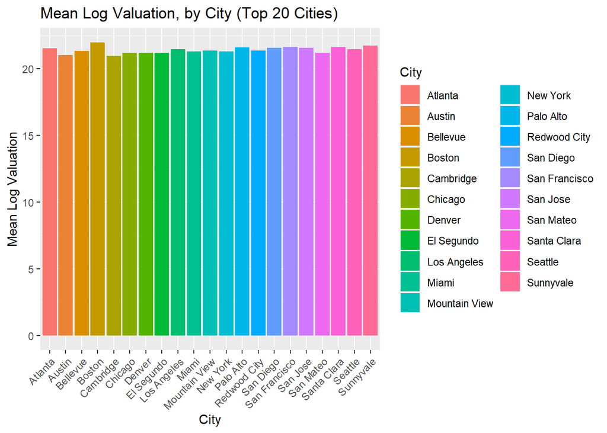

```r
ggplot(data = city_means2, aes(x=City, y= Valuation...B..mean, fill=City)) +
  geom_bar(stat = "identity") +
  theme(axis.text.x = element_text(angle = 45, hjust = 1))  +
  xlab("City") + ylab("Mean Log Valuation") +
  ggtitle("Mean Log Valuation, by City (Top 20 Cities)")
```

### Side Analysis

```r
lm2 <- lm(Valuation...B. ~ City, large_cities)

summary(lm2)
```

```
##
## Call:
## lm(formula = Valuation...B. ~ City, data = large_cities)
##
## Residuals:
##     Min      1Q  Median      3Q     Max
## -0.9935 -0.5673 -0.2272  0.3857  3.6255
##
## Coefficients:
##                   Estimate Std. Error t value Pr(>|t|)
## (Intercept)       21.52201    0.28426  75.714   <2e-16 ***
## CityAustin        -0.48529    0.40200  -1.207    0.228
## CityBellevue      -0.19711    0.44037  -0.448    0.655
## CityBoston         0.44938    0.34081   1.319    0.188
## CityCambridge     -0.56831    0.41841  -1.358    0.175
## CityChicago       -0.32313    0.34081  -0.948    0.344
## CityDenver        -0.32167    0.44037  -0.730    0.466
## CityEl Segundo    -0.30992    0.44037  -0.704    0.482
## CityLos Angeles   -0.04415    0.38923  -0.113    0.910
## CityMiami         -0.20943    0.44037  -0.476    0.635
## CityMountain View -0.15844    0.34081  -0.465    0.642
## CityNew York      -0.23144    0.29444  -0.786    0.432
## CityPalo Alto      0.08881    0.34081   0.261    0.795
## CityRedwood City  -0.15823    0.37062  -0.427    0.670
## CitySan Diego      0.05995    0.41841   0.143    0.886
## CitySan Francisco  0.12966    0.29104   0.446    0.656
## CitySan Jose       0.05215    0.40200   0.130    0.897
## CitySan Mateo     -0.31254    0.37062  -0.843    0.400
## CitySanta Clara    0.13096    0.41841   0.313    0.754
## CitySeattle       -0.04497    0.40200  -0.112    0.911
## CitySunnyvale      0.20482    0.40200   0.510    0.611
## ---
## Signif. codes:  0 '***' 0.001 '**' 0.01 '*' 0.05 '.' 0.1 ' ' 1
##
## Residual standard error: 0.7521 on 385 degrees of freedom
## Multiple R-squared:  0.08023,    Adjusted R-squared:  0.03245
## F-statistic: 1.679 on 20 and 385 DF,  p-value: 0.03425
```

```r
summary(lm2)$r.squared
```

```
## [1] 0.08022759
```

It turns out that our R-squared goes down, and that we don’t find any cities with statistically significant relationships at the 95% confidence level.

Also, we are going to try to see if there’s a dependency between number of unicorns and city/industry.

```r
library(dplyr)
lm3 <- lm(group_num ~ City, company_cities)
summary(lm3)
```

```
##
## Call:
## lm(formula = group_num ~ City, data = company_cities)
##
## Residuals:
##        Min         1Q     Median         3Q        Max
## -3.936e-12 -6.110e-14 -2.830e-14  0.000e+00  4.354e-12
##
## Coefficients:
##                           Estimate Std. Error    t value Pr(>|t|)
## (Intercept)              1.000e+00  6.144e-13  1.628e+12  < 2e-16 ***
## CityAmbler              -3.955e-13  8.689e-13 -4.550e-01 0.649240
## CityArlington           -8.966e-14  8.689e-13 -1.030e-01 0.917860
## CityAtlanta              6.000e+00  6.568e-13  9.135e+12  < 2e-16 ***
## CityAustin               6.000e+00  6.568e-13  9.135e+12  < 2e-16 ***
## CityBellevue             4.000e+00  6.731e-13  5.943e+12  < 2e-16 ***
## CityBellingham           1.923e-12  8.689e-13  2.213e+00 0.027432 *
## CityBend                -3.242e-12  8.689e-13 -3.731e+00 0.000217 ***
## CityBerkeley             1.000e+00  7.525e-13  1.329e+12  < 2e-16 ***
## CityBerkeley Heights    -1.061e-12  8.689e-13 -1.222e+00 0.222574
## CityBethesda            -2.585e-12  8.689e-13 -2.975e+00 0.003104 **
## CityBoca Raton           8.156e-13  8.689e-13  9.390e-01 0.348440
## CityBoise                7.235e-13  8.689e-13  8.330e-01 0.405505
## CityBoston               1.500e+01  6.333e-13  2.368e+13  < 2e-16 ***
## CityBoulder              1.000e+00  7.525e-13  1.329e+12  < 2e-16 ***
## CityBrisbane            -3.098e-13  8.689e-13 -3.570e-01 0.721592
## CityBrooklyn             1.000e+00  7.525e-13  1.329e+12  < 2e-16 ***
## CityBurlingame           1.000e+00  7.525e-13  1.329e+12  < 2e-16 ***
## CityBurlington          -6.533e-13  8.689e-13 -7.520e-01 0.452590
## CityCambridge            5.000e+00  6.636e-13  7.534e+12  < 2e-16 ***
## CityCarlsbad             8.580e-13  8.689e-13  9.870e-01 0.324011
## CityCarson City          2.155e-12  8.689e-13  2.480e+00 0.013525 *
## CityCary                -1.044e-12  8.689e-13 -1.202e+00 0.230056
## CityCedar Park          -3.451e-12  8.689e-13 -3.971e+00 8.41e-05 ***
## CityCharlotte            1.000e+00  7.525e-13  1.329e+12  < 2e-16 ***
## CityChatham             -2.325e-12  8.689e-13 -2.676e+00 0.007754 **
## CityChicago              1.500e+01  6.333e-13  2.368e+13  < 2e-16 ***
## CityCincinnati          -8.518e-13  8.689e-13 -9.800e-01 0.327495
## CityColorado Springs    -1.801e-12  8.689e-13 -2.073e+00 0.038771 *
## CityColumbus             2.290e-13  8.689e-13  2.630e-01 0.792303
```

[output cut: 79 more lines]

```
## CityTustin              -1.729e-15  8.689e-13 -2.000e-03 0.998413
## CityWalnut              -3.484e-15  8.689e-13 -4.000e-03 0.996803
## CityWalpole              3.925e-13  8.689e-13  4.520e-01 0.651716
## CityWaltham              1.000e+00  7.525e-13  1.329e+12  < 2e-16 ***
## CityWashington           1.000e+00  7.525e-13  1.329e+12  < 2e-16 ***
## CityWashington DC        1.000e+00  7.525e-13  1.329e+12  < 2e-16 ***
## CityWesterville         -1.346e-24  8.689e-13  0.000e+00 1.000000
## CityWilmington          -1.348e-24  8.689e-13  0.000e+00 1.000000
## CityZephyr Cove         -1.347e-24  8.689e-13  0.000e+00 1.000000
## ---
## Signif. codes:  0 '***' 0.001 '**' 0.01 '*' 0.05 '.' 0.1 ' ' 1
##
## Residual standard error: 6.144e-13 on 418 degrees of freedom
## Multiple R-squared:      1,  Adjusted R-squared:      1
## F-statistic: 4.577e+28 on 117 and 418 DF,  p-value: < 2.2e-16
```

```r
company_industries = uni_company %>%
  group_by(Industry) %>%
  mutate(group_num = n()) %>%
  distinct(Industry, .keep_all = TRUE)

company_cities = company_cities %>%
  distinct(City, .keep_all = TRUE)

lm4 <- lm(group_num ~ 0 + Industry, company_industries)
summary(lm4)
```

```
##
## Call:
## lm(formula = group_num ~ 0 + Industry, data = company_industries)
##
## Residuals:
## ALL 16 residuals are 0: no residual degrees of freedom!
##
## Coefficients:
##                                             Estimate Std. Error t value
## IndustryArtificial intelligence                   40        NaN     NaN
## IndustryArtificial Intelligence                    3        NaN     NaN
## IndustryAuto & transportation                      3        NaN     NaN
## IndustryConsumer & retail                         11        NaN     NaN
## IndustryCybersecurity                             38        NaN     NaN
## IndustryData management & analytics               31        NaN     NaN
## IndustryE-commerce & direct-to-consumer           30        NaN     NaN
## IndustryEdtech                                     7        NaN     NaN
## IndustryFintech                                  109        NaN     NaN
## IndustryHardware                                  10        NaN     NaN
## IndustryHealth                                    50        NaN     NaN
## IndustryInternet software & services             143        NaN     NaN
## IndustryMobile & telecommunications               12        NaN     NaN
## IndustryOther                                     28        NaN     NaN
## IndustrySupply chain, logistics, & delivery       20        NaN     NaN
## IndustryTravel                                     1        NaN     NaN
##                                             Pr(>|t|)
## IndustryArtificial intelligence                  NaN
## IndustryArtificial Intelligence                  NaN
## IndustryAuto & transportation                    NaN
## IndustryConsumer & retail                        NaN
## IndustryCybersecurity                            NaN
## IndustryData management & analytics              NaN
## IndustryE-commerce & direct-to-consumer          NaN
## IndustryEdtech                                   NaN
## IndustryFintech                                  NaN
## IndustryHardware                                 NaN
## IndustryHealth                                   NaN
## IndustryInternet software & services             NaN
## IndustryMobile & telecommunications              NaN
## IndustryOther                                    NaN
## IndustrySupply chain, logistics, & delivery      NaN
## IndustryTravel                                   NaN
##
## Residual standard error: NaN on 0 degrees of freedom
## Multiple R-squared:      1,  Adjusted R-squared:    NaN
## F-statistic:   NaN on 16 and 0 DF,  p-value: NA
```

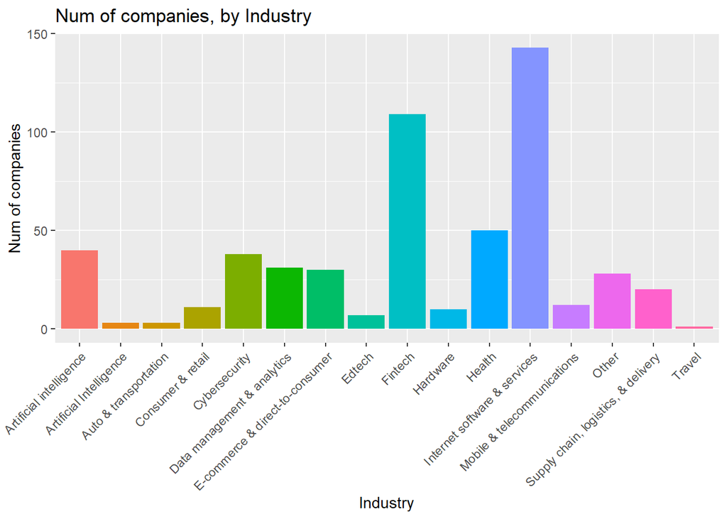

```r
ggplot(company_industries, aes(x=Industry, y=group_num, fill=Industry)) +
   geom_bar(stat = "identity") +
   guides(fill = FALSE) +
  xlab("Industry") + ylab("Num of companies") +
  theme(axis.text.x = element_text(angle = 45, hjust = 1))  +
  ggtitle("Num of companies, by Industry")
```

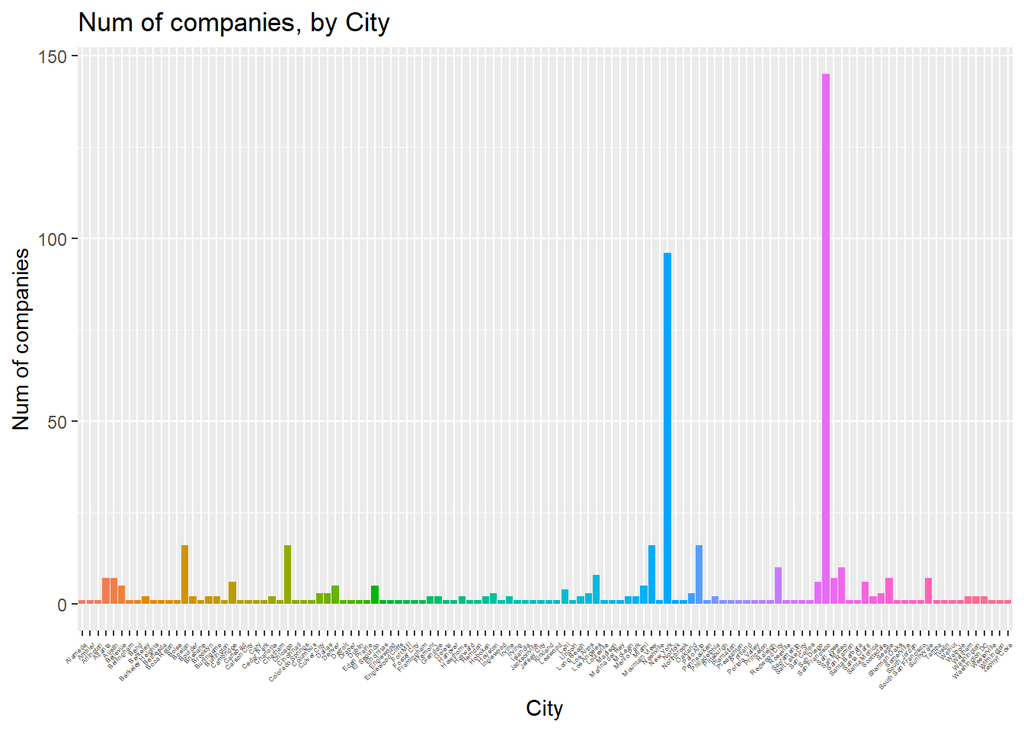

```r
ggplot(company_cities, aes(x=City, y=group_num, fill=City)) +
   geom_bar(stat = "identity") +
   guides(fill = FALSE) +
  xlab("City") + ylab("Num of companies") +
  theme(axis.text.x = element_text(angle = 45, hjust = 1, size = 3.5))  +
  ggtitle("Num of companies, by City")
```